# Homework 5 - Modeling in R

Loading data

```r
library(statisticalModeling)
library(tidyverse)
library(ggplot2)
library(dplyr)
require(broom)
load("data_sim1.Rda")
data_sim1
```

| x | y |
| --- | --- |
| 1 | 4.920286 |
| 2 | 9.015812 |
| 3 | 11.027928 |
| 4 | 12.898078 |
| 5 | 20.903263 |
| 6 | 25.035733 |

## Basic fitting of a model using R and tidyverse packages

Let’s start by fitting a linear model using the built in package.

```r
#fit a linear model for y using x
# linear_model <- lm ( ? )
linear_model <- lm ( y ~x, data=data_sim1)
summary(linear_model)
```

```
Call:
lm(formula = y ~ x, data = data_sim1)

Residuals:
      1       2       3       4       5       6
 0.8184  0.9680 -0.9659 -3.0418  1.0174  1.2039

Coefficients:
            Estimate Std. Error t value Pr(>|t|)
(Intercept)   0.1559     1.7588   0.089 0.933638
x             3.9460     0.4516   8.738 0.000945 ***
---
Signif. codes:  0 ‘***’ 0.001 ‘**’ 0.01 ‘*’ 0.05 ‘.’ 0.1 ‘ ’ 1

Residual standard error: 1.889 on 4 degrees of freedom
Multiple R-squared:  0.9502,    Adjusted R-squared:  0.9378
F-statistic: 76.35 on 1 and 4 DF,  p-value: 0.0009453
```

```r
# get the coefficients from the model
# tidy is a trick to make the model object from lm into a data frame
#   makes it easier to extract parts of it
#   -> you can access them with paramters[1] to get the intercept, [2] for the slope
parameters = tidy(linear_model)$estimate
# calculate the predictions from the lm model and add them to the data_sim1
# remember that the equation of a line is y = intercept + slope*x
# uncomment these lines and fix as needed
data_sim1 <- data_sim1 %>%
  mutate(
    linear_model_prediction = parameters[1] + parameters[2]*x
  )
```

## Tidy modeling with broom

You added the predictions above manually. Packages like broom help you add predictions automatically. This is similar to some of the packages in the Datacamp course, but those packages in the statisticalModeling library aren’t well-maintained / lack some flexibility (even though they are very good). People use broom more in practice.

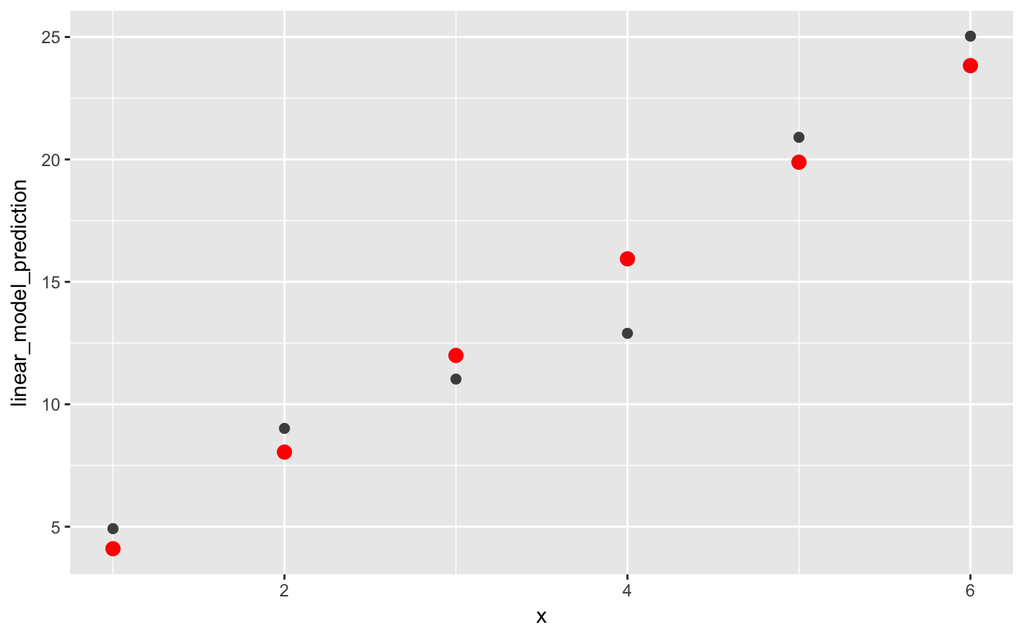

```r
# use broom package to add predicted values to our dataset from the model
# (called .fitted ; same as model_output for )
# other values are added too like .residual = actual-.fitted
data_with_model_output <- augment(linear_model, data=data_sim1)
#let's plot the data and the prediction
# do this for data_sim1 then data_with_model_output
#    to check these methods are equivalent
# hint: make the first layer have the predictions with larger sized points
#     so the actual data can be put on top of it
ggplot(data_sim1 , aes(x)) +
  geom_point(aes(y= linear_model_prediction), size = 3, colour = "red") +
  geom_point(aes(y= y), size = 2, colour = "grey30")
```

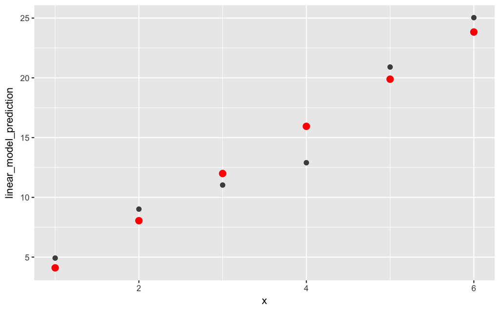

```r
ggplot(data_with_model_output , aes(x)) +
  geom_point(aes(y= linear_model_prediction), size = 3, colour = "red") +
  geom_point(aes(y= y), size = 2, colour = "grey30")
```

Do you think this is a good model for the data set? Why? Yes, because the prediction and actual values are close, with the exception of one outlier.

What information would help you answer the question above better? Legends, and lines to connect the dots would help.  
# Does faculty salary vary by gender and/or rank?

(modified from assignment from Mike Freeman’s INFO370 class)

Let’s begin by reading in some data from [this course website](http://data.princeton.edu/wws509/datasets/#salary). Columns included are:

```
- **sx** = Sex, coded 1 for female and 0 for male
- **rk** = Rank, coded
    - 1 for assistant professor,
    - 2 for associate professor, and
    - 3 for full professor
- **yr** = Number of years in current rank
- **dg** = Highest degree, coded 1 if doctorate, 0 if masters
- **yd** = Number of years since highest degree was earned
- **sl** = Academic year salary, in dollars.
```

```r
library(readr)
faculty <- read_table(url("http://data.princeton.edu/wws509/datasets/salary.dat"))
glimpse(faculty)
```

```
Observations: 52
Variables: 6
$ sx <chr> "male", "male", "male", "female", "male", "male", "female", "male", "male", "male", "male", "male", "male", "male", "m...
$ rk <chr> "full", "full", "full", "full", "full", "full", "full", "full", "full", "full", "full", "associate", "full", "associat...
$ yr <int> 25, 13, 10, 7, 19, 16, 0, 16, 13, 13, 12, 15, 9, 9, 9, 7, 13, 11, 10, 6, 16, 8, 7, 8, 9, 5, 11, 5, 3, 3, 10, 11, 9, 4,...
$ dg <chr> "doctorate", "doctorate", "doctorate", "doctorate", "masters", "doctorate", "masters", "doctorate", "masters", "master...
$ yd <int> 35, 22, 23, 27, 30, 21, 32, 18, 30, 31, 22, 19, 17, 27, 24, 15, 20, 14, 15, 21, 23, 31, 13, 24, 12, 18, 14, 16, 7, 17,...
$ sl <int> 36350, 35350, 28200, 26775, 33696, 28516, 24900, 31909, 31850, 32850, 27025, 24750, 28200, 23712, 25748, 29342, 31114,...
```

## Descriptive statistics by gender

Before doing any modeling, you should get a basic feel for the gender breakdown in your dataset.

Write code for each of the below:

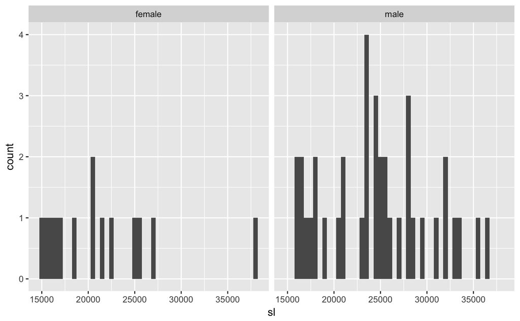

```r
# What is the number of males/females in the dataset? What does this already tell you...?
#38 males, 14 females
male<- nrow(filter(faculty, sx == "male"))
female<-nrow(filter(faculty, sx == "female"))
# What is the mean salary by sex? Hint: you'll have to groupby sex (`sx`)
mean_salary_sex <- faculty %>% select(sl,sx) %>%group_by(sx) %>% summarise(mean = mean(sl))
# Draw histograms for the distribution of salaries for males and females (separately)
# Hint: you can use ggplot and facet
# The x and y axes should be consistent between the graphs
ggplot(data = faculty, aes(x = sl)) + geom_histogram(binwidth = 500) + facet_wrap(~ sx)
```

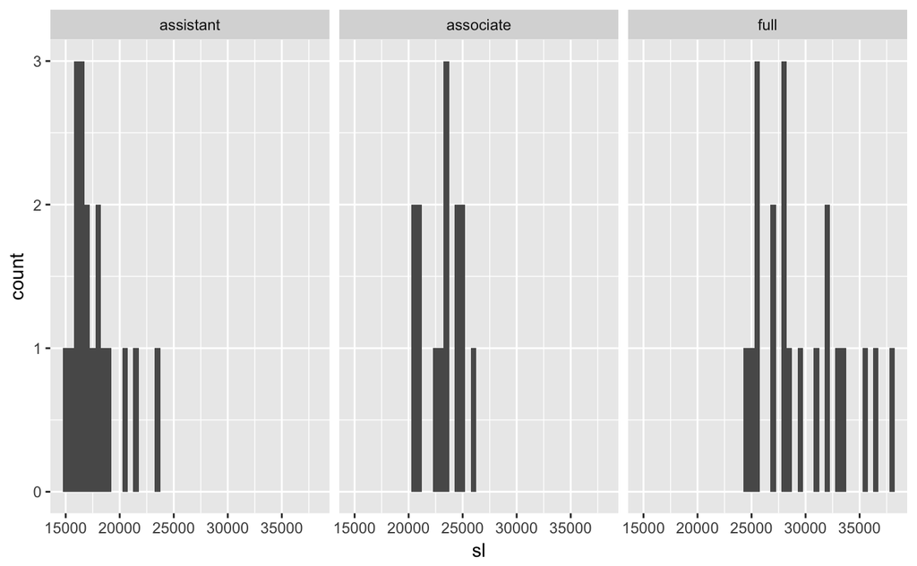

```r
# Draw histograms for the distribution of salaries by rank
ggplot(data = faculty, aes(x = sl)) + geom_histogram(binwidth = 500) + facet_wrap(~ rk)
```

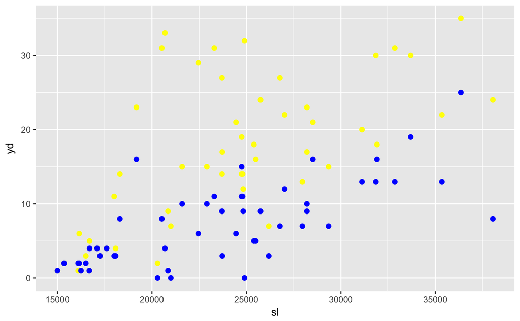

```r
# Create scatterplots to show how salary compares to years since degree / in current rank
ggplot(data = faculty, aes(x = sl)) + geom_point(aes(y= yd), size = 2, colour = "yellow") + geom_point(aes(y = yr), size = 2,colour = "blue")
```

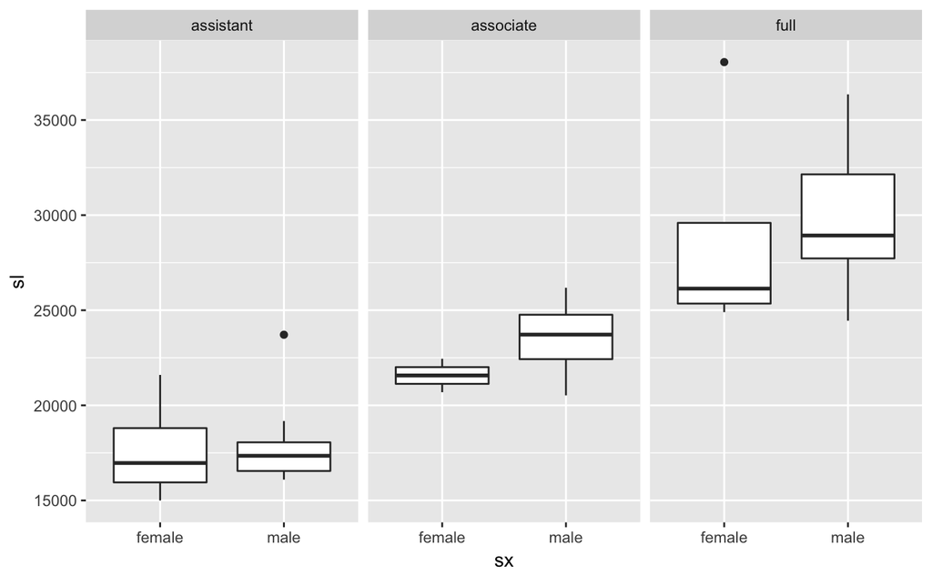

```r
# Create plots of salary (by gender) for each rank
ggplot(data = faculty, aes(x = sx)) + geom_boxplot(aes(y= sl)) + facet_wrap(~ rk)
```

```r
# What do these tell you about gender discrimination on the faculty?
# Generally for associate and full professor, males earn a lot more then a females. For assistant professor, there is not a big difference, but males still earn more on average.
```

## Simple linear regression: what is the salary increase associated with each additional year in your current position (yr)?

```r
# Create a simple linear model that assesses the relationship between
# years in current position with salary
model_1 <- lm(yr ~ sl, data = faculty)
# What is the effect size of years on salary? Also interpret the effect size in words.
# Hint: you can use tools from statisticalModeling package used in the Datacamp course
effect_size <- effect_size(model_1, ~ sl)
#effect_size measures the the change in salary per year
# Evaluate the accuracy of your model. Calculate a metric for it.
evaluate_model(model_1)
```

| sl | model_output |
| --- | --- |
| 10000 | -1.517370 |
| 20000 | 5.004129 |
| 30000 | 11.525629 |

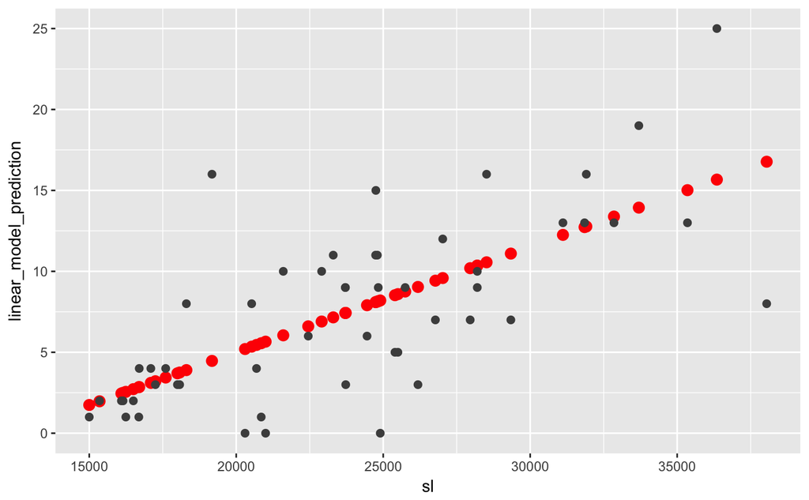

```r
# Interpret the metric for accuracy above.
# 11.525629-5.004129= 6.5215
# Draw a scatterplot with your model on it to show how well the model fits the data
# Hint: broom and ggplot may be useful here
parameters = tidy(model_1)$estimate
faculty <- faculty %>%
  mutate(
    linear_model_prediction = parameters[1] + parameters[2]*sl
  )
data_with_model_output <- augment(model_1, data=faculty)
ggplot(data_with_model_output , aes(sl)) +
  geom_point(aes(y= linear_model_prediction), size = 3, colour = "red") +
  geom_point(aes(y= yr), size = 2, colour = "grey30")
```